# Getting Started with Genomic Prediction

Updated April 23, 2025

```r
#library(bigRR)
library(tidyverse)
library(reshape2)
library(rrBLUP)
library(BGLR)
library(gridExtra)
library(snowfall)
library(hglm)
#load("Genome_Prediction_Fits.Rdata")
```

```r
source("bigRR/R/bigRR.R")
source("bigRR/R/bigRR_update.R")
source("bigRR/R/bigRR-internal.R")
source("bigRR/R/bigRR.default.R")
source("bigRR/R/bigRR.formula.R")
source("bigRR/R/plot.bigRR.R")
source("bigRR/R/print.bigRR.R")
source("bigRR/R/hat.transf.R")
```

## RMarkdown presentation

This presentation made in R Markdown.

The file is available at:

https://github.com/jnmaloof/Hypocotyl_Genomic_prediction/Genomic_Prediction_IntBio.Rmd

(Or on IntBio Google Drive)

## Genomic Prediction Intro

## Goal: Need to predict phenotype from genotype

- Need a single number per individual for IPM demography models
- Use genomic data to predict growth, survival, reproduction, etc.

## One possiblity: polygenic score (PGS)

- Use GWAS to find markers linked to trait of interest
- A separate statistical model is fit for each SNP to determine significance and allelic effect in the training population

\(growth \sim \beta0 + \beta1*SNP1\)

\(growth \sim \beta0 + \beta2*SNP2\)

\(growth \sim \beta0 + \beta3*SNP3\)

…

\(growth \sim \beta * SNP5000000\)

## GWAS PGS predictions

- Genotype new individuals
- Predictions are made by summing the allelic effects at each SNP based on the training GWAS

\[PGS = \sum_{j=1}^{snps} \beta j *SNPj\]

- Challenges:
  - setting significance threshold (may miss out on small-effect loci or include irrelevant loci)
  - can overestimate effect size of main loci (Beavis effect)
- Still worth exploring…and method updates may alleviate some concerns

## Genomic Prediction

- Try to estimate the effects of all loci simultaneously
- GWAS fits a separate regression model for each location being considered

\(growth \sim \beta0 + \beta1*SNP1\)

\(growth \sim \beta0 + \beta2*SNP2\)

\(growth \sim \beta0 + \beta3*SNP3\)

…

\(growth \sim \beta * SNP5000000\)

- Genomic prediction fits a model to all markers simultaneously

\(growth \sim \beta1*SNP1 + \beta2*SNP2 + \beta3*SNP3 + ... +\beta5000000*SNP5000000\)

## Genomic Prediction

- Genomic prediction fits a model to all markers simultaneously

\(growth \sim \beta1*SNP1 + \beta2*SNP2 + \beta3*SNP3 + ... +\beta5000000*SNP5000000\)

- Once this model is fit then we can predict the performance of new individuals
- Challenge: How to fit a regression model with millions of predictors?

## Fitting a model (standard regression)

What is the best value for \(\beta\)?

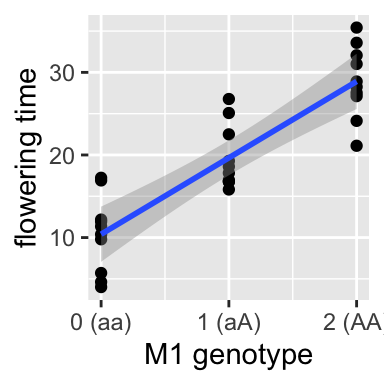

In standard regression with one or just a few predictors, \(growth \sim \beta1*SNP1\), choose the \(\beta\) that minimizes the residual sum of squares (RSS), i.e the distance from the line \[ RSS = \sum_{i=1}^n (y_i - \beta_0 + \beta_1*SNP1_i )^2\]

## RSS more than one predictor

Instead of

\[ RSS = \sum_{i=1}^n (y_i - \beta_0 + \beta_1*SNP1_i )^2\]

For more than one predictor, we can generalize as \[ RSS = \sum_{i=1}^n (y_i - \beta_0 + \sum_{j=1}^{snps}\beta_j*SNP_{i,j} )^2 \]

## Fitting model (penalized regression)

- Standard regression models do not perform well with many predictors
- If we expect that most predictors will have an effect size of ~ 0 (we do in this case), use *penalized regression*
- Penalized regression *penalizes* models based on the number of predictors. For example (lasso), minimize: \[ \sum_{i=1}^n (y_i - \beta_0 + \sum_{j=1}^{snps}\beta_j*SNP_{i,j} )^2 + \lambda \sum_{j=1}^{snps}|\beta_j| \]

\[ = RSS + \lambda \sum_{j=1}^{snps}|\beta_j|\]

- Where \(\lambda\) is a tuning parameter
- “Penalize” models for non-zero coefficients
- Other versions include Ridge Regression, Elastic Net

## Other multi-loci methods for predictions

- Random Forests (with boosting, etc). This has outperformed penalized regression in my hands
- Bayesian penalized regression
  - Use priors strongly biased towards zero
  - Horseshoe, Laplace, Student’s T, etc.
  - There are also specialized Bayesian models for genomic prediction (package BGLR)

## Example

## hypocotyls

- Use hypocotyl data set from Filiault and Maloof (2012)
- 169 Arabidopsis natural accessions
- 250,000 SNPs

## bigRR

- Package bigRR (big Ridge Regression) uses optimized code to fit penalized Ridge Regression models.
- Enables separate shrinkage parameters to be used for each marker, in a two-step process

## Two steps of model validation

We need to test the genomic prediction models that we create:

1. Compare fitted data with observations. Can the model reproduce the observations used to create the model?
2. Split the data into “training” and “test” sets.

## BigRR Fitted vs original, all data

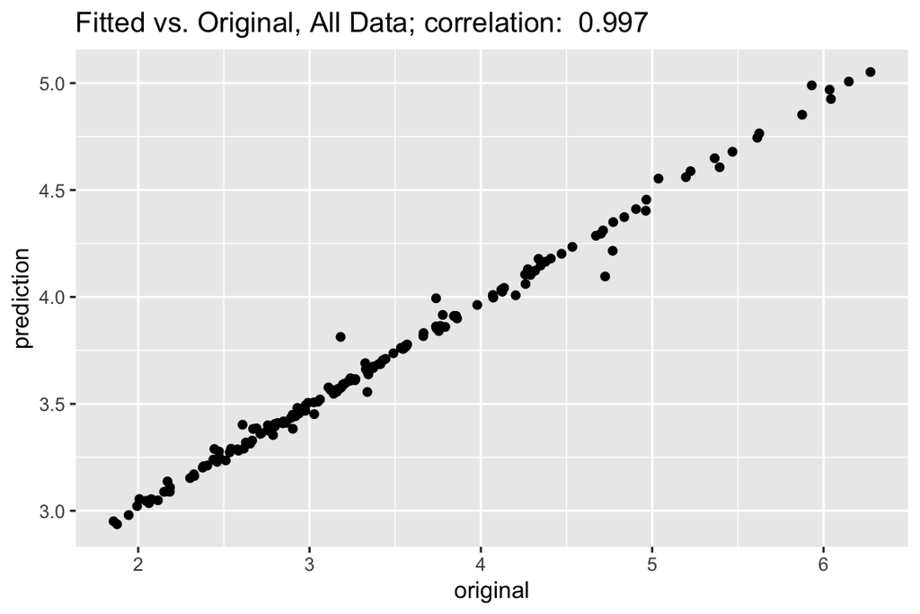

So at least the model can reproduce the original data.

## predict new observations

Here create 10 training / test sets where the training sets are a randomly picked 75% of the lines and the test sets are the remaining 25%.

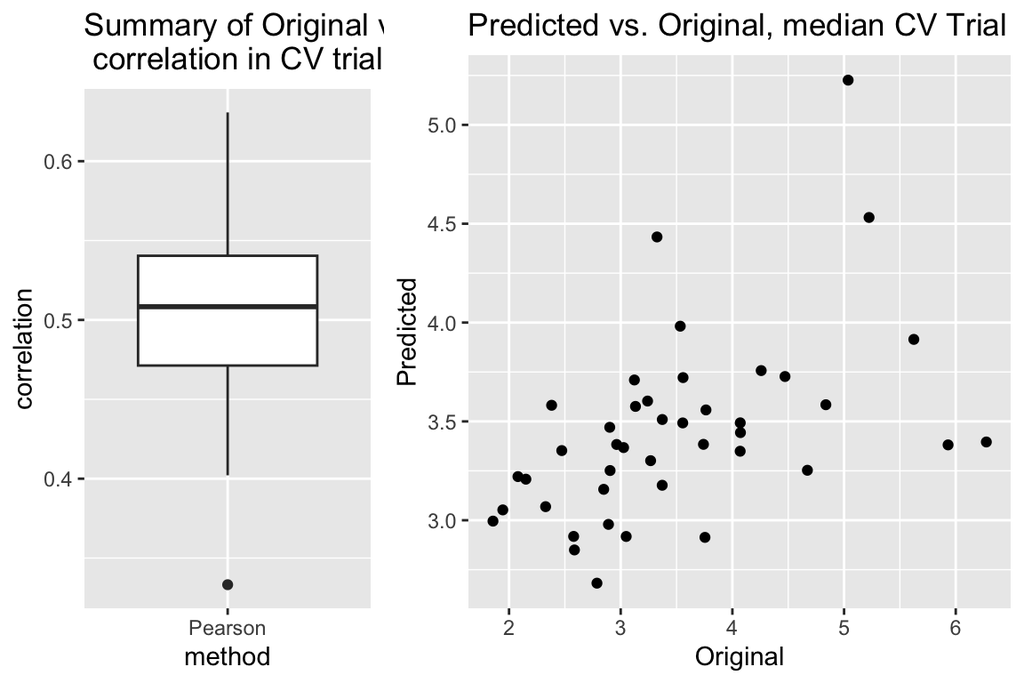

Not awesome, but this is a v. small sample size (169 plants)